# Quality Control: Filtering & Trimming Amplicon Sequences

Emily Wahly

April 21, 2026

```r
set.seed(236530)
```

```r
# What time did we start running this script?
start_time <- Sys.time()
start_time
```

```
## [1] "2026-04-21 19:40:38 EDT"
```

```r
# Efficient package loading with pacman
pacman::p_load(tidyverse, dada2, patchwork,
               DT, devtools, Biostrings, ShortRead,
               install = FALSE)
```

# 0. Prepare Raw fastq Files

```r
# Set the raw fastq path to the raw sequencing files
# Path to the fastq files
raw_fastqs_path <- "/local/workdir/erw98/Brassica_Growth_2026/data/00_raw_gzipped_fastqs"
raw_fastqs_path
```

```
## [1] "/local/workdir/erw98/Brassica_Growth_2026/data/00_raw_gzipped_fastqs"
```

```r
# What files are in this path? Intuition Check
head(list.files(raw_fastqs_path))
```

```
## [1] "SRR11917047_1.fastq.gz" "SRR11917047_2.fastq.gz" "SRR11917048_1.fastq.gz"
## [4] "SRR11917048_2.fastq.gz" "SRR11917049_1.fastq.gz" "SRR11917049_2.fastq.gz"
```

```r
# How many files are there?
length(list.files(raw_fastqs_path))
```

```
## [1] 504
```

```r
# Create vector of forward reads
forward_reads <- list.files(raw_fastqs_path, pattern = "_1.fastq.gz", full.names = TRUE)

# Intuition Checks
head(forward_reads)
```

```
## [1] "/local/workdir/erw98/Brassica_Growth_2026/data/00_raw_gzipped_fastqs/SRR11917047_1.fastq.gz"
## [2] "/local/workdir/erw98/Brassica_Growth_2026/data/00_raw_gzipped_fastqs/SRR11917048_1.fastq.gz"
## [3] "/local/workdir/erw98/Brassica_Growth_2026/data/00_raw_gzipped_fastqs/SRR11917049_1.fastq.gz"
## [4] "/local/workdir/erw98/Brassica_Growth_2026/data/00_raw_gzipped_fastqs/SRR11917050_1.fastq.gz"
## [5] "/local/workdir/erw98/Brassica_Growth_2026/data/00_raw_gzipped_fastqs/SRR11917051_1.fastq.gz"
## [6] "/local/workdir/erw98/Brassica_Growth_2026/data/00_raw_gzipped_fastqs/SRR11917052_1.fastq.gz"
```

```r
# Intuition check #2: We should have fewer reads in the forward vector than in total
stopifnot(length(forward_reads) < length(list.files(raw_fastqs_path)))
length(forward_reads)
```

```
## [1] 252
```

```r
# Create a vector of reverse reads
reverse_reads <- list.files(raw_fastqs_path, pattern = "_2.fastq.gz", full.names = TRUE)

# Intuition Checks
head(reverse_reads)
```

```
## [1] "/local/workdir/erw98/Brassica_Growth_2026/data/00_raw_gzipped_fastqs/SRR11917047_2.fastq.gz"
## [2] "/local/workdir/erw98/Brassica_Growth_2026/data/00_raw_gzipped_fastqs/SRR11917048_2.fastq.gz"
## [3] "/local/workdir/erw98/Brassica_Growth_2026/data/00_raw_gzipped_fastqs/SRR11917049_2.fastq.gz"
## [4] "/local/workdir/erw98/Brassica_Growth_2026/data/00_raw_gzipped_fastqs/SRR11917050_2.fastq.gz"
## [5] "/local/workdir/erw98/Brassica_Growth_2026/data/00_raw_gzipped_fastqs/SRR11917051_2.fastq.gz"
## [6] "/local/workdir/erw98/Brassica_Growth_2026/data/00_raw_gzipped_fastqs/SRR11917052_2.fastq.gz"
```

```r
# Intuition check #2: Need to have equal number of forward and reverse files
stopifnot(length(reverse_reads) == length(forward_reads))
length(reverse_reads)
```

```
## [1] 252
```

# 1. Assess Raw Read Quality

## Evaluate raw sequence quality

## Plot 12 random samples of plots

```r
# Randomly select 12 samples from dataset to evaluate
random_samples <- sample(1:length(reverse_reads), size = 12)
random_samples
```

```
##  [1] 233 231  17 189 148 150 211 217  78  11 106  65
```

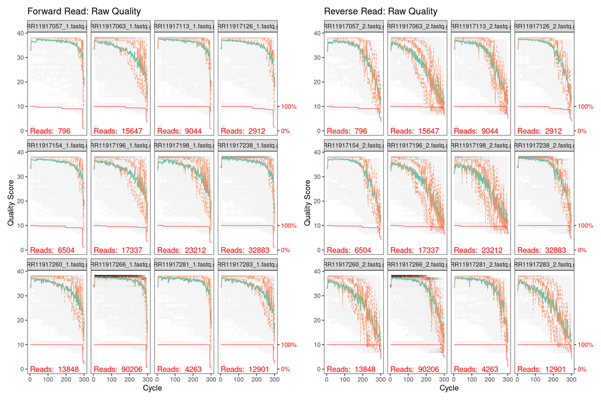

```r
# Calculate and plot quality of these 12 samples
forward_filteredQual_plot_12 <- plotQualityProfile(forward_reads[random_samples]) +
  labs(title = "Forward Read: Raw Quality")
reverse_filteredQual_plot_12 <- plotQualityProfile(reverse_reads[random_samples]) +
  labs(title = "Reverse Read: Raw Quality")

# Plot them together with patchwork
forward_filteredQual_plot_12 + reverse_filteredQual_plot_12
```

**Acceptable Phred Scores for ASVs with DADA2**

In DADA2, quality filtering is crucial for obtaining reliable biological sequences. Below are the acceptable **Phred score** thresholds for DADA2 preprocessing:

| **Q Score** | **Error Probability** | **DADA2 Interpretation** |
| --- | --- | --- |
| **40** | 0.0001 (1 in 10,000) | Very high-quality , dream come true |
| **≥30** | ≤ 0.001 (1 in 1,000) | Excellent quality, keep |
| **25-30** | ~0.003 - 0.01 | Can be acceptable, but more important to trim low-quality tails |
| **20-25** | ~0.01 - 0.03 | Lower quality, only acceptable if read length is absolutely critical |
| **<20** | > 0.01 (1 in 100) | Poor quality, remove |
| **<10** | >0.1 (1 in 10) | Very unreliable, absolutely remove |

Some summary take-aways:

- **30 is good** – Bases with Q30+ scores have a **99.9% accuracy rate**, making them highly reliable.
- **25-30 can be acceptable**, but trimming is preferred to remove low-quality tails.
- **20-25** should only be kept if read length is absolutely critical (*e.g.* to ensure forward & reverse read overlap)
- **<20 discarded** – Bases with Phred scores below 20 have an **error rate >1%** and should 100% be **trimmed from the dataset**.

## Aggregated Raw Quality Plots

Next, we will plot all of the samples aggregated into one forward (left) and one reverse read (right) plot.

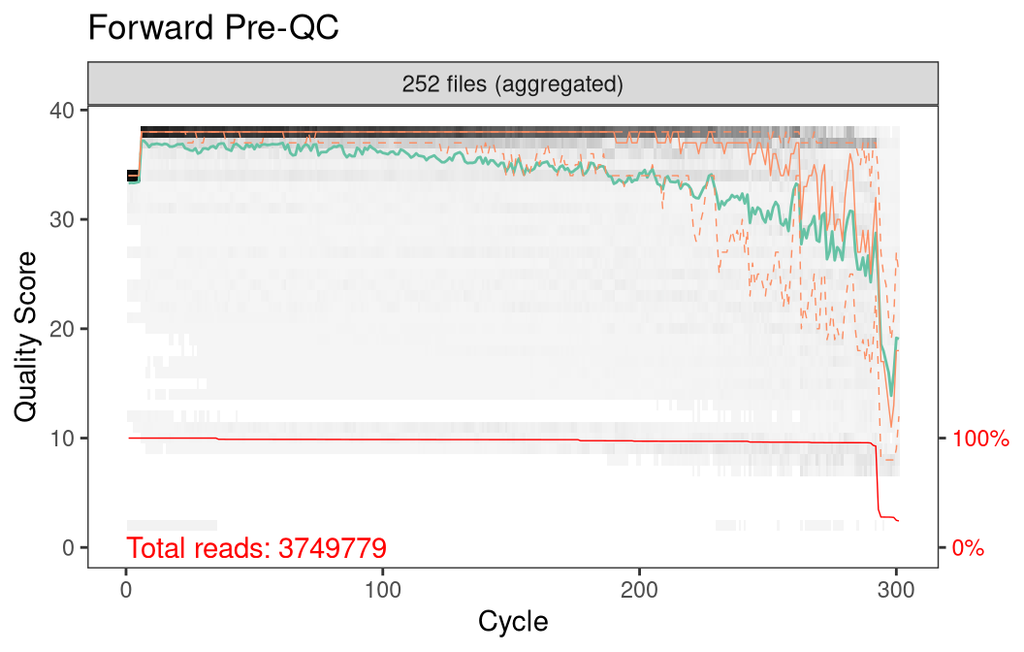

```r
# Aggregate all QC plots
# Forward reads
forward_preQC_plot <-
  plotQualityProfile(forward_reads, aggregate = TRUE) +
  labs(title = "Forward Pre-QC")
forward_preQC_plot
```

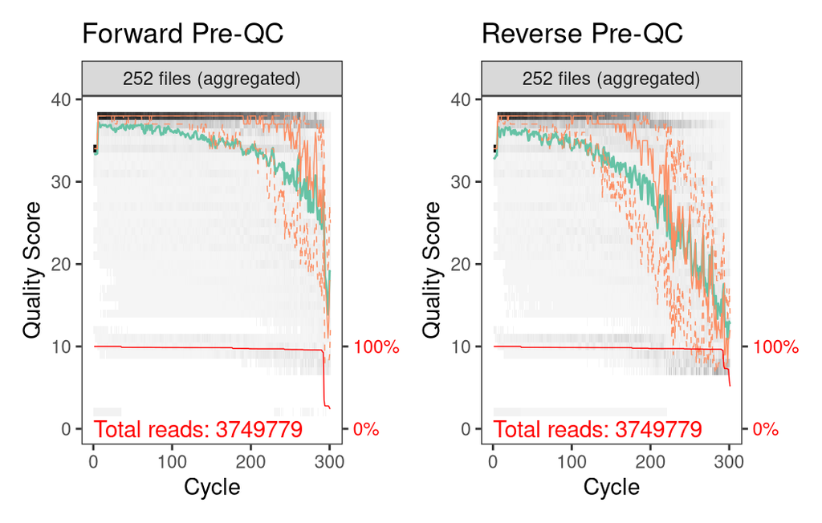

```r
# reverse reads
reverse_preQC_plot <-
  plotQualityProfile(reverse_reads, aggregate = TRUE) +
  labs(title = "Reverse Pre-QC")

# Now, let's put the two plots together
preQC_aggregate_plot <-
  # Plot the forward and reverse together
  forward_preQC_plot + reverse_preQC_plot
# Show the plot
preQC_aggregate_plot
```

#2. Check for Primers